# YouTube Ads: Observing Patterns in Product Types and Tone

## Introduction

This visual data story presents insights from observing YouTube advertisements. Data was collected using a Google Form to track ad types, tone, ad count, and viewing time. The purpose was to explore whether patterns emerge in the kinds of ads shown, their tone, and whether viewing time influences what gets advertised.

I collected all observations myself, and no personal data was included. This ensures a privacy-respecting, ethical data collection process.

## Methodology

Observations were made across multiple sessions while watching YouTube. I recorded the timestamp, ad count, tone, product category, and viewing time. I later added a question: “What time of day did you watch the video?” to explore time-based trends.

Data was cleaned using `lubridate`, and ads containing tech-related keywords were flagged using `str_detect()` from `{stringr}`. Visualisations were created using `{ggplot2}` and saved with `ggsave()`.

## Ad Types Observed

This bar chart shows the frequency of different ad types. It highlights which product categories are most commonly targeted to viewers.

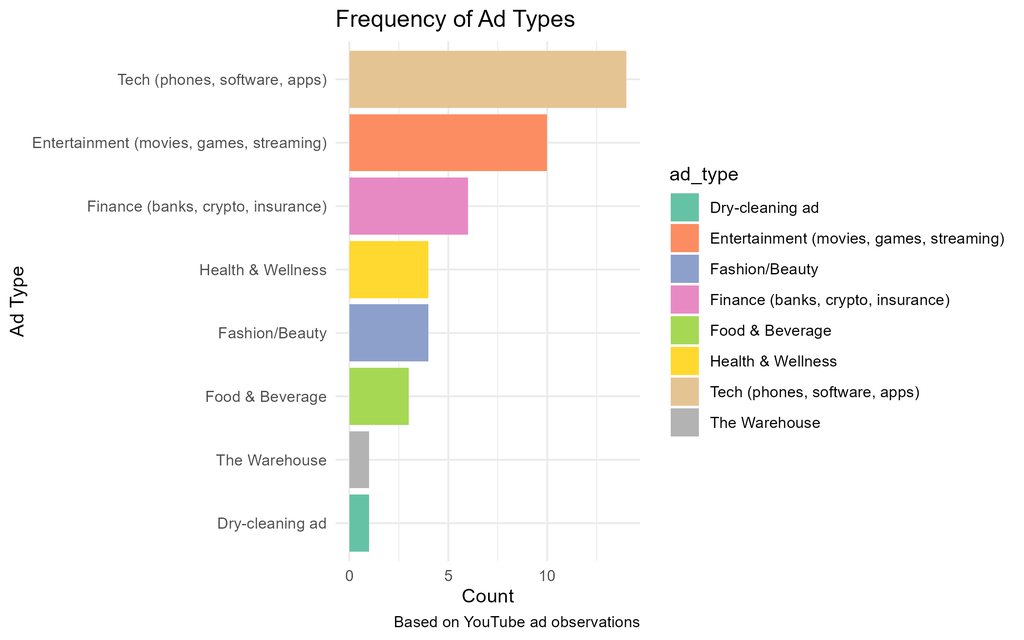

(plot1.png)

## Tone of Ads by Time of Day

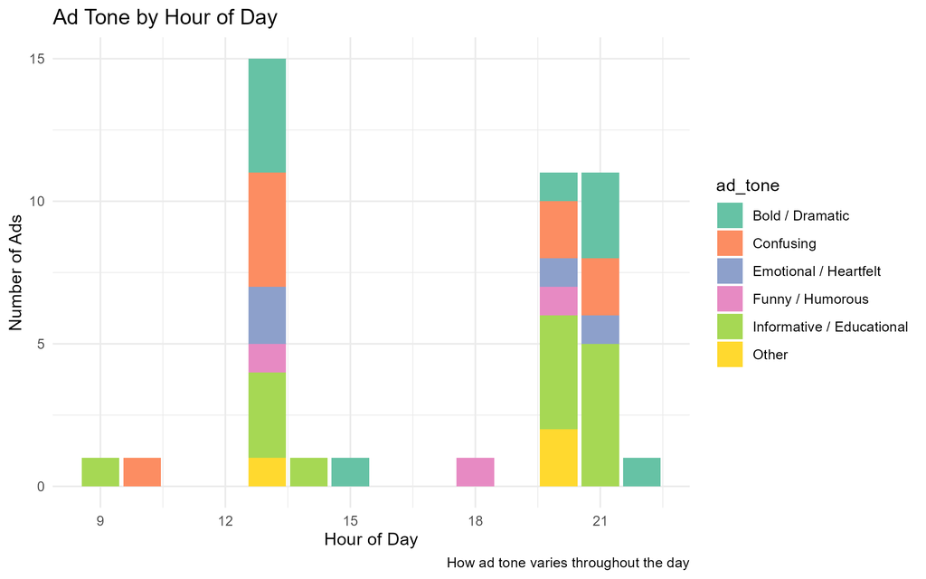

(plot2.png)

## Proportion of Tech Ads

This pie chart visualises the proportion of ads that are tech-related, determined using keyword matching. It shows the significant share of technology ads in the sample.

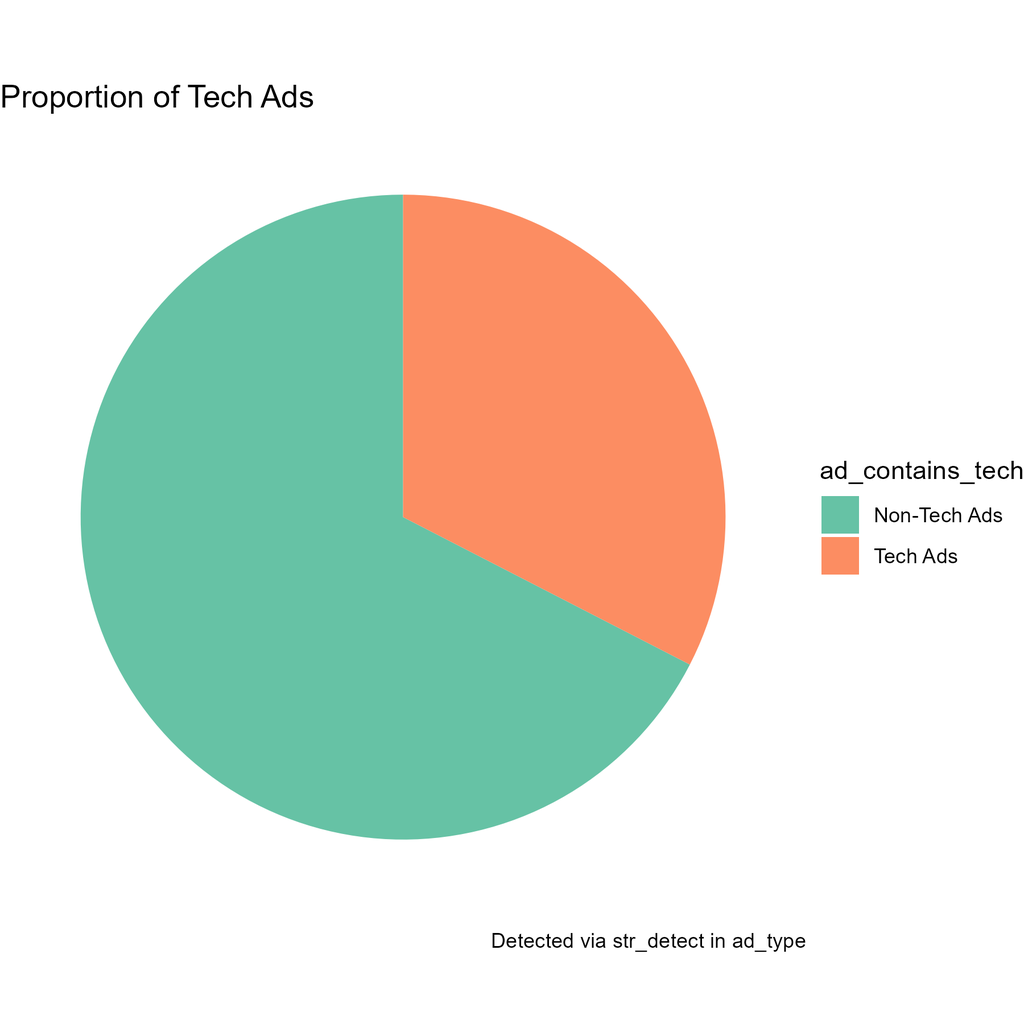

(plot3.png)

## Summary and Reflection

Challenges included dealing with messy timestamps and long column names from Google Forms. I learned to use `group_by()`, `summarise()`, `str_detect()`, `mutate()`, `arrange()`, and `slice()` to wrangle and visualise data effectively. Plot aesthetics were improved using a consistent colour palette from ColorBrewer and minimalist themes.

All plots were saved using `ggsave()` and are fully reproducible via the `data_visualisation.R` script.